# Quarto example

Author

Mathieu Marauri

This document is an illustration of a [Quarto](https://quarto.org/) document. The installation is done from the [official website](https://quarto.org/docs/get-started/).

# How to use

2 main options are available:

1. Using VScode
2. Using Jupyter Notebook

## VScode

You need to install the Quarto extension and to generate a new quarto document. Select the python interpreter to be the one from your virtual environment and you are good to go.

## Jupyter

Build your Jupyter Notebook as usual, simply add a YAML in the very first cell (a raw one). Call `quarto render` and you have an HTML or a PDF document. You an also call `quarto peview` to see live updates of the generated document as you make changes to your notebook.

# Markdown

The text content is written in Mardown so lists, links, *italic*, **bold**, … are done the same way as usual. If the output is an html document you can embed html tags if needed. If a pdf is rendered, LaTex code is possible. In any case formulas can be writen in LaTex[^1].

## Section titles

You can number section with the option `number-sections: true` in the YAML. You can prevent one section to appear in the table of contents.

### Skipped section

This section will not appear in the toc.

## LaTex formulas

$$X \sim \mathcal{N}(\mu,\,\sigma^{2})$$

# Python code

You can write python code within code chunks. The code will be executed and the output of the code, if any, will be display on the document. There are different [execution options](https://quarto.org/docs/computations/execution-options.html) available for code chunks.

## Code without output

The code specified in chunks can be shown in the output or kept hidden. The main chunk options to focus on are `echo` and `eval`.

Here we load data from the `data` folder. It contains digits from the MNIST dataset.

```python
# Load the train dataset
train = pd.read_csv('../data/train.csv')

# Build X_train and a y_train objects
X_train = train.drop(columns='label')
y_train = train['label']

# Reshape the data to an array of 28x28 images, dimensions expected by the model that will be built
X_train = np.array(X_train).reshape(-1,28,28,1)
```

## Inline code

The following is written using inline code.

The shape of the train set is (42000, 28, 28, 1).

## Figures

You can use code chunks to produce plots and to display them.

Figure 1 displays the distribution of digits in the training set.

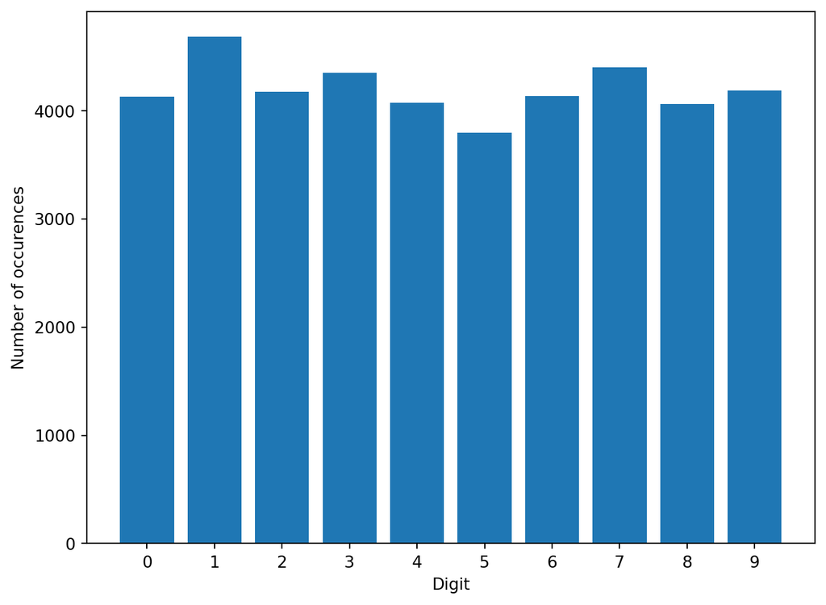

Figure 1: Distribution of digits in the training set

We can also display 2 plots side-by-side as in Figure 2, Figure 2 (a) is the same plot as the previous one.

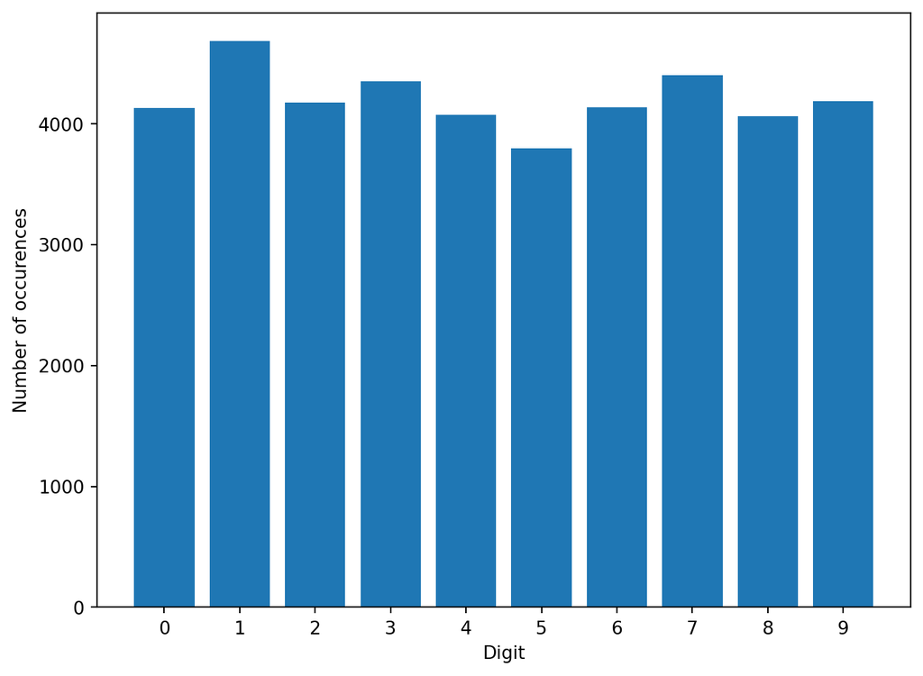

(a) Distribution of digits in the training set

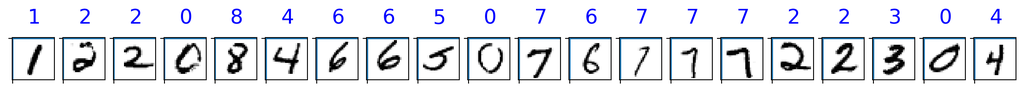

(b) Example of digits

Figure 2: Preview of the training data

## Footnotes

[^1]: It will be examplified in a dedicated section, see Section 2.2